# Лабораторна робота №2. Робота в середовищі Anaconda

## Тема. Налаштування та робота в середовищі Anaconda+Quarto

**Мета**: швидкий старт для роботи в середовищі Anaconda із застосуванням Jupyter Notebook, або Jupyter Notebook засобами мови програмування Python та видавничої системи Quarto.

Виконав:Черниш В'ячеслав 08.12.2024

## Хід роботи

[figure not shown]

2.Через інтерфейс командного рядка налагодити за допомогою conda віртуальне середовище з ім’ям _OpenCV. Етапи роботи підтвердити скріншотами.

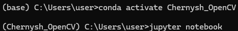

3. Проінсталювати у створене середовище пакети, необхідні для роботи з OpenCV.

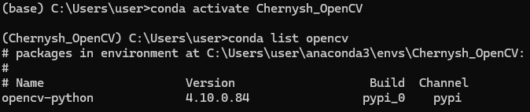

4. Створити Notebook-документ <lab_2_StudentLastName> за допомогою

Jupyter Notebook.

[figure not shown]

5. Надати відповіді на контрольні запитання.

   1 Що таке pip і conda та чим вони відрізняються між собою?

   pip — це пакетний менеджер для встановлення Python-бібліотек з PyPI, а conda — універсальний менеджер пакетів і середовищ, який підтримує Python і інші мови, маючи власний репозиторій; основна відмінність у широті можливостей та сумісності з залежностями.

   2 Як буде виглядати виконання пунктів 1–3 індивідуального завдання за допомогою Virtualenv?

   Virtualenv є частиною Python, а Conda вимагає окремого встановлення

   3 Сфотографувати себе на телефон та імпортувати свое зображення у форматі .png

[figure not shown]

4 Написати процедуру на Python сортування масиву методом бульбашки.

```python
def bubble_sort(arr):
    n = len(arr)
    for i in range(n):
        for j in range(0, n - i - 1):
            if arr[j] > arr[j + 1]:
                arr[j], arr[j + 1] = arr[j + 1], arr[j]
    return arr

arr = [99, 3, 6, 1, 9, 13, 73, 63, 7, 8, 52]
print("Вихідний масив:", arr)
bubble_sort(arr)
print("Відсортований масив:", arr)
```

```
Вихідний масив: [99, 3, 6, 1, 9, 13, 73, 63, 7, 8, 52]
Відсортований масив: [1, 3, 6, 7, 8, 9, 13, 52, 63, 73, 99]
```

5 Як виконати компіляцію вхідного документа Jupyter Notebook із його середовища, не використовуючи інтерфейс командного рядка?

File -> Save And Export Notebook As -> HTML (Або інший тип)

6 Як виконати компіляцію вхідного документа у Quarto?

Написати у командному рядку quarto render name